# 10_plot_GWAS_results

Heather Wheeler

2016-03-11 14:38:32

Load packages, functions, paths

```r
library(dplyr)
```

```r
library(tidyr)
library(ggplot2)
library(calibrate)
library(knitr)
"%&%" = function(a,b) paste(a,b,sep="")
my.dir = "/Volumes/dolan-lab/hwheeler/ThePlatinumStudy/GWAS/"
source(my.dir %&% "genotypes/qqunif.r")
source(my.dir %&% "manhattan.R")
#qq-man plot function
gwasplots = function(filevec){
  for(file in filevec){
    gwas <- read.table(file,header=T)
    print(file)
    gwas <- gwas[complete.cases(gwas),] #rm NAs
    gwas <- dplyr::filter(gwas,FRQ>=0.05,FRQ<=0.95,INFO<1.05) ##The INFO metric is calculated based on the entire file, based on the ratio of empirical and expected variance in dosage. Values closer to 1 indicate better expected quality of imputation. Values can be above 1: note that values much greater than 1 can indicate strong departure from HWE. from http://pngu.mgh.harvard.edu/~purcell/plink/dosage.shtml
#    saveRDS(gwas$SNP,file=my.dir %&% "genotypes/UMich_imputation_results/mach_dosage_files/N88.imputed_MAF0.05_INFOlt1.05_SNPlist.rds") #for filtering prior to ordreg
    qq<-qqunif(gwas$P,plot=TRUE)
    man<-manhattan(gwas,suggestiveline = FALSE, col=c("green", "blue", "purple"), annotatePval = 1e-06)
    qq
    man
    cat('\n')
    tophits <- dplyr::filter(gwas,P<=1e-06) %>% arrange(P)
    print(kable(tophits))
    cat('\n')
  }
}
```

## rnGM412 = SNP + ageaudio + CumlCispdose + 10 PCs

### PLINK code:

`plink --fam genotypes/N88.forImputation.fam --dosage plink-doselist.txt list sepheader format=1 --pheno genotypes/PtStudy.phenofile --linear --pheno-name rnGM412 --covar genotypes/PtStudy.covfile --map genotypes/UMich_imputation_results/mach_dosage_files/N88.imputed_maf0.01_R20.8_1000G.chr${i}.bim --out GWAS_results/N88.imputed_rnGM412_${covtag}_chr${i}`

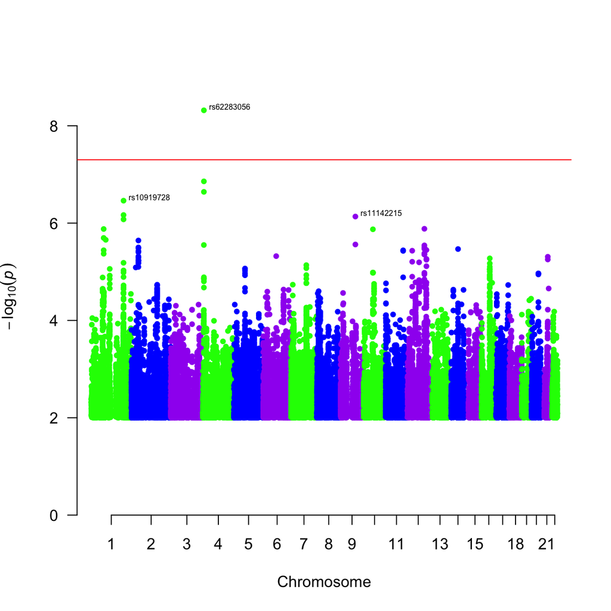

```r
filelist <- c(my.dir %&% "GWAS_results/N88.imputed_rnGM412_age.cisp.10PCs_chr1-22.assoc.dosage")
#gwasplots(filelist)
gwas <- read.table(filelist,header=T)
gwas <- gwas[complete.cases(gwas),] #rm NAs
gwas <- dplyr::filter(gwas,FRQ>=0.05,FRQ<=0.95,INFO<1.05)
gwas2 <- dplyr::filter(gwas,P<0.01)
#only plot SNPs with P<0.01
manhattan(gwas2,suggestiveline = FALSE, col=c("green", "blue", "purple"), annotatePval = 1e-06)
```

```r
#jpeg(filename= my.dir %&% "plots/rnGM412_age.dose.10PCs_manplot.jpeg",width=480,height=360,res=100)
#manhattan(gwas,suggestiveline = FALSE, col=c("green", "blue", "purple"), annotatePval = 1e-06)
#manhattan(gwas,suggestiveline = FALSE, col=c("green", "blue", "purple"))
#dev.off()
summary(gwas$P)
```

Min. 1st Qu. Median Mean 3rd Qu. Max. 0.0000 0.2429 0.4938 0.4952 0.7467 1.0000

```r
#qqunif(gwas$P,plot=TRUE)
#jpeg(filename= my.dir %&% "plots/rnGM412_age.dose.10PCs_qqplot.jpeg")
#qqunif(gwas$P,plot=TRUE)
#dev.off()
tophits <- dplyr::filter(gwas,P<=1e-06) %>% arrange(P)
tophits
```

CHR SNP BP A1 A2 FRQ INFO BETA SE P 1 4 rs62283056 6276630 C G 0.2112 0.9651 0.3540 0.0594 4.816e-09 2 4 rs62283057 6276805 T C 0.1660 0.9543 0.3533 0.0661 1.389e-07 3 4 rs17718958 6275735 A G 0.1683 0.9650 0.3428 0.0653 2.281e-07 4 1 rs10919728 199578450 A T 0.3682 0.9325 0.2659 0.0515 3.463e-07 5 1 rs6662178 199582376 G A 0.3577 1.0314 0.2485 0.0494 6.823e-07 6 9 rs11142215 90897140 G A 0.1564 0.9487 -0.3383 0.0674 7.331e-07 7 1 rs10919727 199578296 G A 0.3294 0.8575 0.2755 0.0552 8.388e-07

## QQ-plot of all SNPs and SNPs in deafness genes

```r
genes<-read.table(my.dir %&% "deafness_genes/N88.imputed_rnGM412_age.cisp.10PCs_chr1-22.assoc.dosage_deafness_genes.txt",header=T) %>% arrange(P)
dim(genes)
```

```
## [1] 12190    15
```

```r
nn = length(genes$P)
xx =  -log10((1:nn)/(nn+1))
jpeg(filename= my.dir %&% "plots/rnGM412_age.dose.10PCs_qqplot_deafness_genes.jpeg",res=100)
qqunif(gwas$P,plot=TRUE,BH=F)
points(xx,-log10(genes$P),cex=0.5,pch=19,col='red')
legend('bottomright', c("Mendelian Deafness\nGene SNPs","All SNPs"),col=c('red','black'), pch=19, cex=1)
dev.off()
```

```r
a<-filter(genes,P<0.01)
dim(a)
```

```
## [1] 230  15
```

```r
unique(a$gene)
```

```
##  [1] WFS1     CLDN14   PCDH15   MARVELD2 KCNQ4    ESRRB    TMC1
##  [8] MYO3A    STRC     MYO7A    USH1C    CDH23
## 42 Levels: ACTG1 CCDC50 CDH23 CLDN14 COCH COL11A2 CRYM DFNA5 ... WFS1
```

```r
a<-filter(genes,P<0.05)
dim(a)
```

```
## [1] 930  15
```

```r
unique(a$gene)
```

```
##  [1] WFS1     CLDN14   PCDH15   MARVELD2 KCNQ4    ESRRB    TMC1
##  [8] MYO3A    STRC     MYO7A    USH1C    CDH23    MYH14    GRHL2
## [15] RDX      OTOF     TMPRSS3  COL11A2  DFNA5    MYO6     DIAPH1
## [22] EYA4     TECTA
## 42 Levels: ACTG1 CCDC50 CDH23 CLDN14 COCH COL11A2 CRYM DFNA5 ... WFS1
```

### top hit rs62283056 is in the first intron of *WFS1* Wolfram syndrome 1 (wolframin):

- This gene encodes a transmembrane protein, which is located primarily in the endoplasmic reticulum and ubiquitously expressed with highest levels in brain, pancreas, heart, and insulinoma beta-cell lines. Mutations in this gene are associated with Wolfram syndrome, also called DIDMOAD (Diabetes Insipidus, Diabetes Mellitus, Optic Atrophy, and Deafness), an autosomal recessive disorder. The disease affects the brain and central nervous system. Mutations in this gene can also cause autosomal dominant deafness 6 (DFNA6), also known as DFNA14 or DFNA38. Alternatively spliced transcript variants have been found for this gene. [provided by RefSeq, Mar 2009]